# Ford GoBike System Data Exploration

## Preliminary Wrangling

This document explores a dataset about individual rides made in a bike-sharing system  
covering the greater San Francisco for the first semester of 2018 and first semester of 2019.

```python
# import all packages and set plots to be embedded inline
import numpy as np
import pandas as pd
import matplotlib.pyplot as plt
import seaborn as sb
import os
import glob

%matplotlib inline
import warnings
warnings.simplefilter("ignore")

sb.set(style="whitegrid")
```

```python
files = os.listdir()
print(files)

df_consolidated = pd.concat([pd.read_csv(f) for f in glob.glob('*-tripdata.csv')], ignore_index = True, sort=False)
df_consolidated.info()
```

```
['.ipynb_checkpoints', '201801-fordgobike-tripdata.csv', '201802-fordgobike-tripdata.csv', '201803-fordgobike-tripdata.csv', '201804-fordgobike-tripdata.csv', '201805-fordgobike-tripdata.csv', '201806-fordgobike-tripdata.csv', '201901-fordgobike-tripdata.csv', '201902-fordgobike-tripdata.csv', '2019…
<class 'pandas.core.frame.DataFrame'>
RangeIndex: 2064003 entries, 0 to 2064002
Data columns (total 17 columns):
duration_sec               int64
start_time                 object
end_time                   object
start_station_id           float64
start_station_name         object
start_station_latitude     float64
start_station_longitude    float64
end_station_id             float64
end_station_name           object
end_station_latitude       float64
end_station_longitude      float64
bike_id                    int64
user_type                  object
member_birth_year          float64
member_gender              object
bike_share_for_all_trip    object
rental_access_method       object
dtypes: float64(7), int64(2), object(8)
memory usage: 267.7+ MB
```

```python
print(df_consolidated.shape)
print(df_consolidated.dtypes)
print(df_consolidated.head(10))
```

```
(2064003, 17)
duration_sec                 int64
start_time                  object
end_time                    object
start_station_id           float64
start_station_name          object
start_station_latitude     float64
start_station_longitude    float64
end_station_id             float64
end_station_name            object
end_station_latitude       float64
end_station_longitude      float64
bike_id                      int64
user_type                   object
member_birth_year          float64
member_gender               object
bike_share_for_all_trip     object
rental_access_method        object
dtype: object
   duration_sec                start_time                  end_time  \
0         75284  2018-01-31 22:52:35.2390  2018-02-01 19:47:19.8240
1         85422  2018-01-31 16:13:34.3510  2018-02-01 15:57:17.3100
2         71576  2018-01-31 14:23:55.8890  2018-02-01 10:16:52.1160
3         61076  2018-01-31 14:53:23.5620  2018-02-01 07:51:20.5000
4         39966  2018-01-31 19:52:24.6670  2018-02-01 06:58:31.0530
5          6477  2018-01-31 22:58:44.8670  2018-02-01 00:46:41.9080
6           453  2018-01-31 23:53:53.6320  2018-02-01 00:01:26.8050
7           180  2018-01-31 23:52:09.9030  2018-01-31 23:55:10.8070
8           996  2018-01-31 23:34:56.0040  2018-01-31 23:51:32.6740
9           825  2018-01-31 23:34:14.0270  2018-01-31 23:47:59.8090

   start_station_id                                 start_station_name  \
0             120.0                               Mission Dolores Park
1              15.0  San Francisco Ferry Building (Harry Bridges Pl...
2             304.0                               Jackson St at 5th St
3              75.0                           Market St at Franklin St
4              74.0                              Laguna St at Hayes St
5             236.0                                Market St at 8th St
6             110.0   17th & Folsom Street Park (17th St at Folsom St)
7              81.0                                 Berry St at 4th St
```

[output cut: 35 more lines]

```
7            -122.391198     1403  Subscriber             1980.0
8            -122.408915     3675  Subscriber             1987.0
9            -121.877349     1453  Subscriber             1994.0

  member_gender bike_share_for_all_trip rental_access_method
0          Male                      No                  NaN
1           NaN                      No                  NaN
2          Male                      No                  NaN
3           NaN                      No                  NaN
4          Male                      No                  NaN
5           NaN                      No                  NaN
6          Male                      No                  NaN
7          Male                      No                  NaN
8          Male                     Yes                  NaN
9        Female                     Yes                  NaN
```

### What is the structure of your dataset?

There are information of the first semester of 2018 and 2019,  
total of 2.064.003 rides in the dataset with 17 features:

- duration_sec,
- start_time,
- end_time,
- start_station_id,
- start_station_name,
- start_station_latitude,
- start_station_longitude,
- end_station_id,
- end_station_name,
- end_station_latitude,
- end_station_longitude,
- bike_id,
- user_type,
- member_birth_year,
- member_gender,
- bike_share_for_all_trip,
- rental_access_method

### What is/are the main feature(s) of interest in your dataset?

The main features in tha dataset is the duration and dates of the rides, with these information it's possible to analyze and draw conclusions.

### What features in the dataset do you think will help support your investigation into your feature(s) of interest?

Together with the duration and dates, I'm looking for correlation of user type.

## Univariate Exploration

```python
df = df_consolidated.copy()
```

In order to analyze the months of start and end time it is necessary to convert them

```python
df['start_time'] = pd.to_datetime(df['start_time'],infer_datetime_format=True, errors='ignore')
df['end_time'] = pd.to_datetime(df['end_time'],infer_datetime_format=True, errors='ignore')
df.dtypes
```

```
duration_sec                        int64
start_time                 datetime64[ns]
end_time                   datetime64[ns]
start_station_id                  float64
start_station_name                 object
start_station_latitude            float64
start_station_longitude           float64
end_station_id                    float64
end_station_name                   object
end_station_latitude              float64
end_station_longitude             float64
bike_id                             int64
user_type                          object
member_birth_year                 float64
member_gender                      object
bike_share_for_all_trip            object
rental_access_method               object
dtype: object
```

Create new columns to take only the **month** value for each variable

```python
df['start_time_month'] = pd.DatetimeIndex(df['start_time']).month
df['end_time_month'] = pd.DatetimeIndex(df['end_time']).month
df.head()
```

|  | duration_sec | start_time | end_time | start_station_id | start_station_name | start_station_latitude | start_station_longitude | end_station_id | end_station_name | end_station_latitude | end_station_longitude | bike_id | user_type | member_birth_year | member_gender | bike_share_for_all_trip | rental_access_method | start_time_month | end_time_month |
| --- | --- | --- | --- | --- | --- | --- | --- | --- | --- | --- | --- | --- | --- | --- | --- | --- | --- | --- | --- |
| 0 | 75284 | 2018-01-31 22:52:35.239 | 2018-02-01 19:47:19.824 | 120.0 | Mission Dolores Park | 37.761420 | -122.426435 | 285.0 | Webster St at O'Farrell St | 37.783521 | -122.431158 | 2765 | Subscriber | 1986.0 | Male | No | NaN | 1 | 2 |
| 1 | 85422 | 2018-01-31 16:13:34.351 | 2018-02-01 15:57:17.310 | 15.0 | San Francisco Ferry Building (Harry Bridges Pl... | 37.795392 | -122.394203 | 15.0 | San Francisco Ferry Building (Harry Bridges Pl... | 37.795392 | -122.394203 | 2815 | Customer | NaN | NaN | No | NaN | 1 | 2 |
| 2 | 71576 | 2018-01-31 14:23:55.889 | 2018-02-01 10:16:52.116 | 304.0 | Jackson St at 5th St | 37.348759 | -121.894798 | 296.0 | 5th St at Virginia St | 37.325998 | -121.877120 | 3039 | Customer | 1996.0 | Male | No | NaN | 1 | 2 |
| 3 | 61076 | 2018-01-31 14:53:23.562 | 2018-02-01 07:51:20.500 | 75.0 | Market St at Franklin St | 37.773793 | -122.421239 | 47.0 | 4th St at Harrison St | 37.780955 | -122.399749 | 321 | Customer | NaN | NaN | No | NaN | 1 | 2 |
| 4 | 39966 | 2018-01-31 19:52:24.667 | 2018-02-01 06:58:31.053 | 74.0 | Laguna St at Hayes St | 37.776435 | -122.426244 | 19.0 | Post St at Kearny St | 37.788975 | -122.403452 | 617 | Subscriber | 1991.0 | Male | No | NaN | 1 | 2 |

Create new columns to take only the **year** value for each variable

```python
df['start_time_year'] = pd.DatetimeIndex(df['start_time']).year
df['end_time_year'] = pd.DatetimeIndex(df['end_time']).year
df.head()
```

|  | duration_sec | start_time | end_time | start_station_id | start_station_name | start_station_latitude | start_station_longitude | end_station_id | end_station_name | end_station_latitude | ... | bike_id | user_type | member_birth_year | member_gender | bike_share_for_all_trip | rental_access_method | start_time_month | end_time_month | start_time_year | end_time_year |
| --- | --- | --- | --- | --- | --- | --- | --- | --- | --- | --- | --- | --- | --- | --- | --- | --- | --- | --- | --- | --- | --- |
| 0 | 75284 | 2018-01-31 22:52:35.239 | 2018-02-01 19:47:19.824 | 120.0 | Mission Dolores Park | 37.761420 | -122.426435 | 285.0 | Webster St at O'Farrell St | 37.783521 | ... | 2765 | Subscriber | 1986.0 | Male | No | NaN | 1 | 2 | 2018 | 2018 |
| 1 | 85422 | 2018-01-31 16:13:34.351 | 2018-02-01 15:57:17.310 | 15.0 | San Francisco Ferry Building (Harry Bridges Pl... | 37.795392 | -122.394203 | 15.0 | San Francisco Ferry Building (Harry Bridges Pl... | 37.795392 | ... | 2815 | Customer | NaN | NaN | No | NaN | 1 | 2 | 2018 | 2018 |
| 2 | 71576 | 2018-01-31 14:23:55.889 | 2018-02-01 10:16:52.116 | 304.0 | Jackson St at 5th St | 37.348759 | -121.894798 | 296.0 | 5th St at Virginia St | 37.325998 | ... | 3039 | Customer | 1996.0 | Male | No | NaN | 1 | 2 | 2018 | 2018 |
| 3 | 61076 | 2018-01-31 14:53:23.562 | 2018-02-01 07:51:20.500 | 75.0 | Market St at Franklin St | 37.773793 | -122.421239 | 47.0 | 4th St at Harrison St | 37.780955 | ... | 321 | Customer | NaN | NaN | No | NaN | 1 | 2 | 2018 | 2018 |
| 4 | 39966 | 2018-01-31 19:52:24.667 | 2018-02-01 06:58:31.053 | 74.0 | Laguna St at Hayes St | 37.776435 | -122.426244 | 19.0 | Post St at Kearny St | 37.788975 | ... | 617 | Subscriber | 1991.0 | Male | No | NaN | 1 | 2 | 2018 | 2018 |

5 rows × 21 columns

```python
df['start_time_year_month'] =  df['start_time_year'].map(str) +'0'+ df['start_time_month'].map(str)
```

Get the **week day** from start and end time

```python
df['start_time_weekday'] = pd.DatetimeIndex(df['start_time']).day_name()
df['end_time_weekday'] = pd.DatetimeIndex(df['end_time']).day_name()
df.head()
```

|  | duration_sec | start_time | end_time | start_station_id | start_station_name | start_station_latitude | start_station_longitude | end_station_id | end_station_name | end_station_latitude | ... | member_gender | bike_share_for_all_trip | rental_access_method | start_time_month | end_time_month | start_time_year | end_time_year | start_time_year_month | start_time_weekday | end_time_weekday |
| --- | --- | --- | --- | --- | --- | --- | --- | --- | --- | --- | --- | --- | --- | --- | --- | --- | --- | --- | --- | --- | --- |
| 0 | 75284 | 2018-01-31 22:52:35.239 | 2018-02-01 19:47:19.824 | 120.0 | Mission Dolores Park | 37.761420 | -122.426435 | 285.0 | Webster St at O'Farrell St | 37.783521 | ... | Male | No | NaN | 1 | 2 | 2018 | 2018 | 201801 | Wednesday | Thursday |
| 1 | 85422 | 2018-01-31 16:13:34.351 | 2018-02-01 15:57:17.310 | 15.0 | San Francisco Ferry Building (Harry Bridges Pl... | 37.795392 | -122.394203 | 15.0 | San Francisco Ferry Building (Harry Bridges Pl... | 37.795392 | ... | NaN | No | NaN | 1 | 2 | 2018 | 2018 | 201801 | Wednesday | Thursday |
| 2 | 71576 | 2018-01-31 14:23:55.889 | 2018-02-01 10:16:52.116 | 304.0 | Jackson St at 5th St | 37.348759 | -121.894798 | 296.0 | 5th St at Virginia St | 37.325998 | ... | Male | No | NaN | 1 | 2 | 2018 | 2018 | 201801 | Wednesday | Thursday |
| 3 | 61076 | 2018-01-31 14:53:23.562 | 2018-02-01 07:51:20.500 | 75.0 | Market St at Franklin St | 37.773793 | -122.421239 | 47.0 | 4th St at Harrison St | 37.780955 | ... | NaN | No | NaN | 1 | 2 | 2018 | 2018 | 201801 | Wednesday | Thursday |
| 4 | 39966 | 2018-01-31 19:52:24.667 | 2018-02-01 06:58:31.053 | 74.0 | Laguna St at Hayes St | 37.776435 | -122.426244 | 19.0 | Post St at Kearny St | 37.788975 | ... | Male | No | NaN | 1 | 2 | 2018 | 2018 | 201801 | Wednesday | Thursday |

5 rows × 24 columns

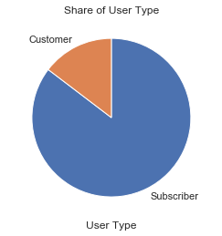

```python
# code for the pie chart using user_type variable
sorted_counts = df['user_type'].value_counts()

plt.xlabel('User Type')
plt.title('Share of User Type')
plt.pie(sorted_counts, labels = sorted_counts.index, startangle = 90,
        counterclock = False)
plt.show();
```

In the pie chart we can notice that user type 'Subscriber' has the bigger share of the rides.  
Plan to investigate if the average of duration it's also higher for the user type 'Subscriber'.

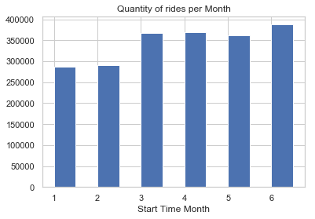

```python
# code for the histogram chart of start_time_month
bin_edges = np.arange(df['start_time_month'].min(), df['start_time_month'].max()+1, 0.5)
plt.xlabel('Start Time Month')
plt.title('Quantity of rides per Month')
plt.hist(data = df, x = 'start_time_month', bins = bin_edges);
```

Considering only the month we can notice that the 6st month (June) has the major quantity of rides,  
plan to investigate if scenario it's commom between the years.

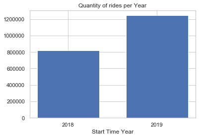

```python
# code for the histogram chart of start_time_year
tick_locs = [2018, 2019]
bin_edges = np.arange(df['start_time_year'].min(), df['start_time_year'].max()+2, 1)
plt.hist(data = df, x = 'start_time_year', bins = bin_edges, align='left', rwidth = 0.7)
plt.xlabel('Start Time Year')
plt.title('Quantity of rides per Year')
plt.xticks(tick_locs, tick_locs);
```

Analyzing the years we can notice that the 2019 year has more rides than the previous year.  
it's by itself shows the growth and dissemination of this kind of transporation.

### Discuss the distribution(s) of your variable(s) of interest. Were there any unusual points? Did you need to perform any transformations?

To obtain the month and year the start_time and end_time needed to be converted  
There were no unusual points so far.

### Of the features you investigated, were there any unusual distributions? Did you perform any operations on the data to tidy, adjust, or change the form of the data? If so, why did you do this?

In order to do the analysis of week day I needed to create new columns in the dataset  
to obtain the information from start_time.

## Bivariate Exploration

[figure not shown]

```python
sb.barplot(data = df, x = 'user_type', y = 'duration_sec')
plt.ylabel('Duration')
plt.xlabel('User Type')
plt.title('Quantity of rides per User Type')
plt.xticks(rotation = 15);
```

[figure not shown]

```python
sb.barplot(data = df, x = 'start_time_year_month', y = 'duration_sec', palette="Blues_d")
plt.xlabel('Start Time Month-Year')
plt.ylabel('Duration')
plt.title('Quantity of rides per Month-Year')
plt.xticks(rotation = 45);
```

[figure not shown]

```python
label = ['Monday', 'Tuesday', 'Wednesday', 'Thursday', 'Friday', 'Saturday', 'Sunday']

sb.barplot(data = df, x = 'start_time_weekday', y = 'duration_sec', order=label, palette="Blues_d")
plt.xlabel('Start Time Week Day')
plt.ylabel('Duration')
plt.title('Quantity of rides per Weekday')
plt.xticks(rotation = 45);
```

```python
# code for the histogram chart of start_time_weekday
df_week_day = df.groupby('start_time_weekday')['duration_sec'].mean()
df_week_day
```

```
start_time_weekday
Friday        791.105170
Monday        769.742941
Saturday     1138.689189
Sunday       1134.116225
Thursday      744.096695
Tuesday       747.591135
Wednesday     738.206867
Name: duration_sec, dtype: float64
```

### Did you observe any interesting relationships between the other features (not the main feature(s) of interest)?

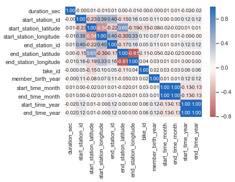

```python
sb.heatmap(df.corr(), annot = True, fmt = '.2f', cmap = 'vlag_r', center = 0);
```

Plotting the variables correlation we can observe that almost none variables has relationship between them

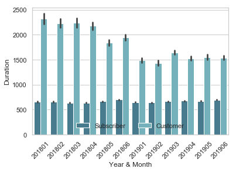

```python
ax = sb.barplot(data = df, x = 'start_time_year_month', y = 'duration_sec', hue = 'user_type', palette='GnBu_d')
ax.legend(frameon=False, loc='lower center', ncol=2)
plt.xlabel('Year & Month')
plt.ylabel('Duration')
plt.xticks(rotation = 45);
```

When we drill down the rides for user type into the months  
we can see that the user Customer has the higher quantity of seconds.

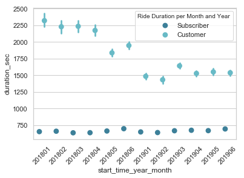

```python
plt.xlabel('Month')
plt.ylabel('Durantion')
ax = sb.pointplot(data = df, x = 'start_time_year_month', y = 'duration_sec', hue = 'user_type',
                  dodge = 0.3, linestyles = "", palette='GnBu_d')
ax.legend(title = 'Ride Duration per Month and Year')
plt.xticks(rotation = 45);
```

### Talk about some of the relationships you observed in this part of the investigation. Were there features that strengthened each other in terms of looking at your feature(s) of interest?

Drill down the user type information were very helpful to understand the relation between this variable  
along the time and how it may impact the way the company are interacting with them.